# Everyday Moments and the Mind :)

- Show All Code
- Hide All Code
- View Source

PSY 120L Reproducible Analysis Report

Author

Sheryl Wiley

Published

June 7, 2026

## About This Report

*This report documents the reproducible data analysis for the PSY 120L study “Everyday Moments and the Mind.” It includes all data preparation steps, scale scoring, statistical analyses, and figures produced in R. The report is structured so that another researcher could follow and replicate each step from raw data to final results*

## Study Overview

*Spending time in nature has been shown to help people feel better and think more clearly. Attention Restoration Theory (ART) suggests that being in natural environments helps restore our ability to focus after it has been worn down by everyday tasks. Stress Reduction Theory (SRT) adds that nature helps the body recover from stress, which also frees up mental storage Studies done with students have found that taking breaks outside leads to better concentration and less mental fatigue compared to taking breaks indoors. This study looked at whether a short outdoor break could improve working memory compared to a short indoor break, and whether that effect was stronger for certain people. We focused on two factors that might matter, stress levels and sex,because past research suggests that people who are more stressed may benefit more from nature, and that males and females may respond to nature differently.We tested five predictions. We expected that participants who took an outdoor break would perform better on the working memory task than those who took an indoor break (H1). We also expected that participants with higher stress levels would perform better on the memory task overall (H2), and that female participants would outperform male participants (H3). Finally, we predicted that the outdoor benefit would be stronger for high-stress individuals than low-stress individuals (H4), and stronger for female participants than male participants (H5)*

*dont change this chunk*

## Setup and Software Environment

*All analyses were conducted in R. The following packages were used: tidyverse for data wrangling and visualization, psych for scale reliability and descriptive statistics, afex for ANOVA models, and emmeans for estimated marginal means and confidence intervals.*

**Load Packages**

```r
library(tidyverse)  # data manipulation + plotting
library(psych)      # scale construction + reliability
library(afex)       # ANOVA models + effect sizes
library(emmeans)    # estimated marginal means + confidence intervals
```

## Data Source and Analysis Dataset

*Participants were undergraduate students at UC Santa Barbara who signed up through a psychology course. After reading and agreeing to a consent form online, they were randomly assigned to either the indoor or outdoor condition through Qualtrics. The data was then imported into R from a .csv file*

### Import Dataset

```r
study_raw <- read_csv("data/moments_mind_data.csv")
```

### Check Imported Dataset

```r
dim(study_raw)
```

```
[1] 84 40
```

```r
names(study_raw)
```

```
 [1] "StartDate"                  "EndDate"
 [3] "Duration (in seconds)"      "Finished"
 [5] "RecordedDate"               "Consent"
 [7] "Timing_Outdoor_First Click" "Timing_Outdoor_Last Click"
 [9] "Timing_Outdoor_Page Submit" "Timing_Outdoor_Click Count"
[11] "Timing_Indoor_First Click"  "Timing_Indoor_Last Click"
[13] "Timing_Indoor_Page Submit"  "Timing_Indoor_Click Count"
[15] "QID34"                      "Break_First Click"
[17] "Break_Last Click"           "Break_Page Submit"
[19] "Break_Click Count"          "Answer1"
[21] "Answer2"                    "Answer3"
[23] "Answer4"                    "Answer5"
[25] "Answer6"                    "Answer7"
[27] "Answer8"                    "PSS_1"
[29] "PSS_2"                      "PSS_3"
[31] "PSS_4"                      "PSS_5"
[33] "PSS_6"                      "PSS_7"
[35] "PSS_8"                      "PSS_9"
[37] "PSS_10"                     "sex"
[39] "age"                        "condition"
```

```r
head(study_raw)
```

```
# A tibble: 6 × 40
  StartDate    EndDate      Duration (in seconds…¹ Finished RecordedDate Consent
  <chr>        <chr>                         <dbl>    <dbl> <chr>          <dbl>
1 5/7/26 12:14 5/7/26 12:30                    910        1 5/7/26 12:30       1
2 5/7/26 13:01 5/7/26 13:12                    648        1 5/7/26 13:12       1
3 5/7/26 16:39 5/7/26 17:00                   1310        1 5/7/26 17:00       1
4 5/7/26 19:34 5/7/26 19:54                   1191        1 5/7/26 19:54       1
5 5/7/26 22:33 5/7/26 22:49                    926        1 5/7/26 22:49       1
6 5/7/26 23:15 5/7/26 23:29                    872        1 5/7/26 23:29       1
# ℹ abbreviated name: ¹`Duration (in seconds)`
# ℹ 34 more variables: `Timing_Outdoor_First Click` <dbl>,
#   `Timing_Outdoor_Last Click` <dbl>, `Timing_Outdoor_Page Submit` <dbl>,
#   `Timing_Outdoor_Click Count` <dbl>, `Timing_Indoor_First Click` <dbl>,
#   `Timing_Indoor_Last Click` <dbl>, `Timing_Indoor_Page Submit` <dbl>,
#   `Timing_Indoor_Click Count` <dbl>, QID34 <chr>, `Break_First Click` <lgl>,
#   `Break_Last Click` <lgl>, `Break_Page Submit` <lgl>, …
```

*The imported dataset contained 84 rows and 40 columns. The output confirmed that all expected variables were present, including condition, demographic variables, timing columns, digit span answer columns, and PSS items*

### Create Analysis Dataset

```r
study_vars <- c(
  "condition", "sex", "age", "Finished", "Consent",

  "Answer1", "Answer2", "Answer3", "Answer4",
  "Answer5", "Answer6", "Answer7", "Answer8",

  "PSS_1", "PSS_2", "PSS_3", "PSS_4", "PSS_5",
  "PSS_6", "PSS_7", "PSS_8", "PSS_9", "PSS_10"
)

study_data <- study_raw %>%
  select(all_of(study_vars)) %>%

    filter(Finished == 1 & !is.na(Finished)) %>%
  filter(Consent == 1 & !is.na(Consent)) %>%

    mutate(
    across(where(is.numeric), as.numeric)
  )
```

### Check Analysis Dataset

```r
length(study_vars)
```

```
[1] 23
```

```r
dim(study_data)
```

```
[1] 83 23
```

```r
names(study_data)
```

```
 [1] "condition" "sex"       "age"       "Finished"  "Consent"   "Answer1"
 [7] "Answer2"   "Answer3"   "Answer4"   "Answer5"   "Answer6"   "Answer7"
[13] "Answer8"   "PSS_1"     "PSS_2"     "PSS_3"     "PSS_4"     "PSS_5"
[19] "PSS_6"     "PSS_7"     "PSS_8"     "PSS_9"     "PSS_10"
```

## Variable Preparation

*This section walks through how all the variables were set up and cleaned before running the analyses.So the coding for condition and sex groups, scoring the memory task, reverse coding the PSS items, and splitting participants into low and high stress groups.*

### Prepare Participant ID and Experimental Condition

```r
study_data <- study_data %>%
  mutate(
    id = row_number(),
    condition = factor(
      condition,
      levels = c(0, 1),
      labels = c("Indoor", "Outdoor")
    ),
    sex = factor(
      sex,
      levels = c(1, 2),
      labels = c("Male", "Female")
    )
  )
```

*Condition had two levels: Indoor (coded 0) and Outdoor (coded 1). Sex was recoded as a factor with two levels: Male (coded 1) and Female (coded 2). A unique participant ID was added to each row using row_number()*

### Check Experimental Condition Coding

```r
study_data %>%
  count(condition) %>%
  knitr::kable(
    col.names = c("Condition", "n")
  )
```

| Condition | n |
| --- | --- |
| Indoor | 43 |
| Outdoor | 40 |

*The table confirms that 43 participants were assigned to the Indoor condition and 40 participants were assigned to the Outdoor condition, reflecting roughly equal group sizes following random assignment*

### Check Prepared Analysis Dataset

```r
dim(study_data)
```

```
[1] 83 24
```

```r
names(study_data)
```

```
 [1] "condition" "sex"       "age"       "Finished"  "Consent"   "Answer1"
 [7] "Answer2"   "Answer3"   "Answer4"   "Answer5"   "Answer6"   "Answer7"
[13] "Answer8"   "PSS_1"     "PSS_2"     "PSS_3"     "PSS_4"     "PSS_5"
[19] "PSS_6"     "PSS_7"     "PSS_8"     "PSS_9"     "PSS_10"    "id"
```

*After adding the participant ID variable, the dataset contains 83 rows and 24 columns. All expected variables are present, including condition, sex, age, Finished, Consent, the eight digit span answer columns, the ten PSS items, and the newly created id variable*

### Score Backward Digit Span

```r
answer_cols <- paste0("Answer", 1:8)
correct_answer8 <- "485268572"

study_data <- study_data %>%
  mutate(
    Answer8_clean = str_remove(as.character(Answer8), "\\.0$"),
    span_score = 8 - rowSums(
      across(
        all_of(answer_cols),
        ~ is.na(.x) | str_trim(as.character(.x)) == ""
      )
    ),
    span_score = if_else(
      span_score == 8 & Answer8_clean == correct_answer8,
      9,
      span_score
    )
  ) %>%
  filter(span_score != 0)
```

### Check Backward Digit Span Scores

```r
study_data %>%
  count(span_score) %>%
  knitr::kable(
    col.names = c("Backward Digit Span Score", "n")
  )
```

| Backward Digit Span Score | n |
| --- | --- |
| 1 | 9 |
| 2 | 8 |
| 3 | 10 |
| 4 | 22 |
| 5 | 23 |
| 6 | 6 |
| 7 | 4 |
| 9 | 1 |

```r
summary(study_data$span_score)
```

```
   Min. 1st Qu.  Median    Mean 3rd Qu.    Max.
  1.000   3.000   4.000   3.988   5.000   9.000
```

### Reverse-Code Scale Items

*Four PSS items (PSS_4, PSS_5, PSS_7, PSS_8) are positively worded and were reverse-coded so that all items are scored in the same direction, where higher values reflect greater perceived stress. Reverse coding was applied using the formula 4 minus the original item value*

```r
study_data <- study_data %>%
  mutate(
    PSS_4r = 4 - PSS_4,
    PSS_5r = 4 - PSS_5,
    PSS_7r = 4 - PSS_7,
    PSS_8r = 4 - PSS_8
  )
```

### Check Reverse Coding

```r
study_data %>%
  select(
    PSS_4, PSS_4r,
    PSS_5, PSS_5r,
    PSS_7, PSS_7r,
    PSS_8, PSS_8r
  ) %>%
  head(10) %>%
  knitr::kable()
```

| PSS_4 | PSS_4r | PSS_5 | PSS_5r | PSS_7 | PSS_7r | PSS_8 | PSS_8r |
| --- | --- | --- | --- | --- | --- | --- | --- |
| 3 | 1 | 3 | 1 | 3 | 1 | 2 | 2 |
| 3 | 1 | 3 | 1 | 2 | 2 | 3 | 1 |
| 3 | 1 | 3 | 1 | 1 | 3 | 2 | 2 |
| 4 | 0 | 2 | 2 | 2 | 2 | 4 | 0 |
| 4 | 0 | 4 | 0 | 2 | 2 | 4 | 0 |
| 2 | 2 | 3 | 1 | 3 | 1 | 1 | 3 |
| 2 | 2 | 1 | 3 | 2 | 2 | 2 | 2 |
| 2 | 2 | 2 | 2 | 2 | 2 | 3 | 1 |
| 3 | 1 | 2 | 2 | 3 | 1 | 1 | 3 |
| 2 | 2 | 2 | 2 | 1 | 3 | 2 | 2 |

### Create Scale Scores

*After reverse coding, a mean composite score and a total sum score were computed across all 10 PSS items. Higher scores indicate greater perceived stress. According to published scoring guidelines, scores of 0–13 reflect low stress, 14–26 moderate stress, and 27–40 high stress*

```r
pss_items <- c(
  "PSS_1", "PSS_2", "PSS_3",
  "PSS_4r", "PSS_5r", "PSS_6",
  "PSS_7r", "PSS_8r", "PSS_9", "PSS_10"
)

study_data <- study_data %>%
  mutate(
    stress_scale = rowMeans(
      across(all_of(pss_items)),
      na.rm = TRUE
    ),
    stress_total = rowSums(
      across(all_of(pss_items)),
      na.rm = TRUE
    )
  )
```

### Check Scale Scores

```r
study_data %>%
  select(
    stress_scale,
    stress_total
  ) %>%
  summary()
```

```
  stress_scale    stress_total
 Min.   :0.300   Min.   : 3.00
 1st Qu.:1.600   1st Qu.:16.00
 Median :1.900   Median :19.00
 Mean   :1.931   Mean   :19.31
 3rd Qu.:2.400   3rd Qu.:24.00
 Max.   :3.100   Max.   :31.00
```

```r
study_data %>%
  summarise(
    stress_scale_missing = mean(is.na(stress_scale)),
    stress_total_missing = mean(is.na(stress_total))
  ) %>%
  knitr::kable()
```

| stress_scale_missing | stress_total_missing |
| --- | --- |
| 0 | 0 |

*The stress scale mean ranged from 0.30 to 3.10 (M = 1.93, Mdn = 1.90), and the stress total ranged from 3 to 31 (M = 19.31, Mdn = 19.00). There were no missing values on either the stress scale or stress total scores, indicating complete PSS data for all 83 participants*

```r
stress_median <- median(study_data$stress_scale, na.rm = TRUE)

study_data <- study_data %>%
  mutate(
    stress_group = if_else(
      stress_scale <= stress_median,
      "Low Stress",
      "High Stress"
    ),
    stress_group = factor(
      stress_group,
      levels = c("Low Stress", "High Stress")
    )
  )

stress_median
```

```
[1] 1.9
```

```r
study_data %>%
  count(stress_group) %>%
  knitr::kable(
    col.names = c("Perceived Stress Group", "n")
  )
```

| Perceived Stress Group | n |
| --- | --- |
| Low Stress | 43 |
| High Stress | 40 |

*Participants were divided into stress groups using a median split on the stress scale mean score (Mdn = 1.90). Participants scoring at or below the median were classified as Low Stress (n = 43) and those scoring above the median were classified as High Stress (n = 40).*

### Check Scale Reliability

*We checked whether the PSS items were measuring the same thing consistently by calculating Cronbach’s alpha and McDonald’s omega in R.*

```r
stress_item_df <- study_data %>%
  select(all_of(pss_items))

stress_alpha <- psych::alpha(stress_item_df)

stress_omega <- psych::omega(stress_item_df, plot = FALSE)

reliability_table <- tibble(
  scale = c("Perceived Stress"),
  alpha = c(stress_alpha$total$raw_alpha),
  omega = c(stress_omega$omega.tot)
)

reliability_table %>%
  mutate(
    alpha = round(alpha, 2),
    omega = round(omega, 2)
  ) %>%
  knitr::kable(
    col.names = c("Scale", "Cronbach's alpha", "McDonald's omega")
  )
```

| Scale | Cronbach’s alpha | McDonald’s omega |
| --- | --- | --- |
| Perceived Stress | 0.82 | 0.86 |

*The PSS demonstrated good internal consistency (α = .82, ω = .86), supporting the reliability of the scale in this sample*

## Descriptive Statistics

*This section summarizes the basic statistics for the two main variables. 1) working memory scores and 2) perceived stress, as well as the sample’s age and sex breakdown*

### Scale Score Descriptives

```r
study_data %>%
  select(span_score, stress_scale, stress_total) %>%
  psych::describe() %>%
  knitr::kable(digits = 2)
```

|  | vars | n | mean | sd | median | trimmed | mad | min | max | range | skew | kurtosis | se |
| --- | --- | --- | --- | --- | --- | --- | --- | --- | --- | --- | --- | --- | --- |
| span_score | 1 | 83 | 3.99 | 1.68 | 4.0 | 4.00 | 1.48 | 1.0 | 9.0 | 8.0 | -0.01 | -0.06 | 0.18 |
| stress_scale | 2 | 83 | 1.93 | 0.59 | 1.9 | 1.94 | 0.59 | 0.3 | 3.1 | 2.8 | -0.12 | -0.38 | 0.06 |
| stress_total | 3 | 83 | 19.31 | 5.89 | 19.0 | 19.36 | 5.93 | 3.0 | 31.0 | 28.0 | -0.12 | -0.38 | 0.65 |

*The descriptive statistics table displays summary information for the three primary study variables. The mean backward digit span score was 3.99 (SD = 1.68, range = 1–9), indicating moderate working memory performance across the sample. The mean perceived stress scale score was 1.93 (SD = 0.59) and the mean perceived stress total score was 19.31 (SD = 5.89), reflecting moderate stress levels overall*

### Sample Composition by Age and Gender

```r
study_data %>%
  count(age) %>%
  mutate(percent = round(100 * n / sum(n), 1)) %>%
  knitr::kable(
    col.names = c("Age Group", "n", "Percent")
  )
```

| Age Group | n | Percent |
| --- | --- | --- |
| 1 | 1 | 1.2 |
| 2 | 77 | 92.8 |
| 3 | 5 | 6.0 |

```r
study_data %>%
  count(sex) %>%
  mutate(percent = round(100 * n / sum(n), 1)) %>%
  knitr::kable(
    col.names = c("Sex", "n", "Percent")
  )
```

| Sex | n | Percent |
| --- | --- | --- |
| Male | 27 | 32.5 |
| Female | 56 | 67.5 |

*The sample was composed of 67.5% female (n = 56) and 32.5% male (n = 27) participants. The majority of participants fell in age group 2 (n = 77, 92.8%), with a small number in age group 3 (n = 5, 6.0%) and age group 1 (n = 1, 1.2%).*

## Correlations Among the DVs

*A Pearson correlation was computed between backward digit span score and perceived stress scale score to examine the relationship between the two dependent variables. Results indicated a near-zero negative correlation between working memory and perceived stress (r = −.09, p = .395), suggesting that perceived stress level was not significantly associated with working memory performance in this sample.*

```r
correlation_results <- psych::corr.test(
  study_data %>%
    select(span_score, stress_scale),
  use = "pairwise"
)

correlation_results$r
```

```
              span_score stress_scale
span_score    1.00000000  -0.09455112
stress_scale -0.09455112   1.00000000
```

```r
correlation_results$p
```

```
             span_score stress_scale
span_score    0.0000000    0.3951889
stress_scale  0.3951889    0.0000000
```

## Primary Analyses

*Two 2×2 between-subjects ANOVAs were conducted to examine the effects of environment condition and moderator variables on backward digit span scores. The first model tested the main effects of condition and sex and their interaction (H1, H3, H5). The second model tested the main effects of condition and perceived stress group and their interaction (H1, H2, H4).*

### Environment Condition × Sex Model

```r
a1_span_sex <- afex::aov_ez(
  id = "id",
  dv = "span_score",
  between = c("condition", "sex"),
  data = study_data
)

a1_span_sex
```

```
Anova Table (Type 3 tests)

Response: span_score
         Effect    df  MSE    F  ges p.value
1     condition 1, 79 2.77 0.20 .003    .654
2           sex 1, 79 2.77 1.00 .012    .322
3 condition:sex 1, 79 2.77 2.42 .030    .123
---
Signif. codes:  0 '***' 0.001 '**' 0.01 '*' 0.05 '+' 0.1 ' ' 1
```

### Estimated Means for Environment Condition × Sex

```r
emmeans(a1_span_sex, ~ condition)
```

```
 condition emmean    SE df lower.CL upper.CL
 Indoor      3.82 0.266 79     3.29     4.35
 Outdoor     4.00 0.287 79     3.43     4.57

Results are averaged over the levels of: sex
Confidence level used: 0.95
```

```r
emmeans(a1_span_sex, ~ sex)
```

```
 sex    emmean    SE df lower.CL upper.CL
 Male     3.72 0.322 79     3.08     4.36
 Female   4.11 0.222 79     3.66     4.55

Results are averaged over the levels of: condition
Confidence level used: 0.95
```

```r
emmeans(a1_span_sex, ~ condition * sex)
```

```
 condition sex    emmean    SE df lower.CL upper.CL
 Indoor    Male     3.93 0.430 79     3.08     4.79
 Outdoor   Male     3.50 0.480 79     2.54     4.46
 Indoor    Female   3.71 0.314 79     3.09     4.34
 Outdoor   Female   4.50 0.314 79     3.87     5.13

Confidence level used: 0.95
```

### Environment Condition × Perceived Stress Group Model

```r
a2_span_stress <- afex::aov_ez(
  id = "id",
  dv = "span_score",
  between = c("condition", "stress_group"),
  data = study_data
)

a2_span_stress
```

```
Anova Table (Type 3 tests)

Response: span_score
                  Effect    df  MSE    F   ges p.value
1              condition 1, 79 2.87 1.24  .015    .269
2           stress_group 1, 79 2.87 0.00 <.001    .989
3 condition:stress_group 1, 79 2.87 0.25  .003    .621
---
Signif. codes:  0 '***' 0.001 '**' 0.01 '*' 0.05 '+' 0.1 ' ' 1
```

### Estimated Means for Environment Condition × Perceived Stress Group

```r
emmeans(a2_span_stress, ~ condition)
```

```
 condition emmean    SE df lower.CL upper.CL
 Indoor      3.78 0.260 79     3.26     4.30
 Outdoor     4.20 0.268 79     3.66     4.73

Results are averaged over the levels of: stress_group
Confidence level used: 0.95
```

```r
emmeans(a2_span_stress, ~ stress_group)
```

```
 stress_group emmean    SE df lower.CL upper.CL
 Low Stress     3.99 0.260 79     3.47     4.51
 High Stress    3.98 0.268 79     3.45     4.52

Results are averaged over the levels of: condition
Confidence level used: 0.95
```

```r
emmeans(a2_span_stress, ~ condition * stress_group)
```

```
 condition stress_group emmean    SE df lower.CL upper.CL
 Indoor    Low Stress     3.88 0.346 79     3.19     4.56
 Outdoor   Low Stress     4.11 0.389 79     3.33     4.88
 Indoor    High Stress    3.68 0.389 79     2.91     4.46
 Outdoor   High Stress    4.29 0.370 79     3.55     5.02

Confidence level used: 0.95
```

## Figures

*The following bar plots display estimated marginal mean backward digit span scores and 95% confidence intervals for each 2×2 design. The error bars show how much the group means could vary*

### Span Score x Sex Interaction Plot

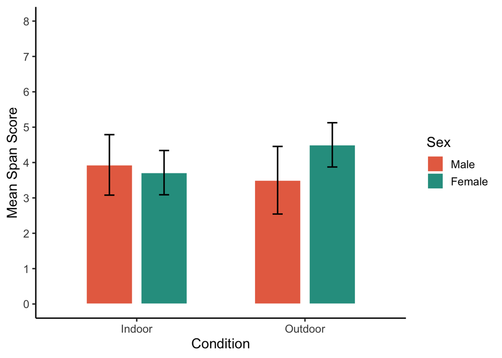

```r
p_span_condition_sex_bar <- ggplot(
  as.data.frame(emmeans(a1_span_sex, ~ condition * sex)),
  aes(
    x = condition,
    y = emmean,
    fill = sex
  )
) +
  geom_col(
    position = position_dodge(width = 0.65),
    width = 0.55,
    color = "white"
  ) +
  geom_errorbar(
    aes(
      ymin = lower.CL,
      ymax = upper.CL
    ),
    position = position_dodge(width = 0.65),
    width = 0.12,
    linewidth = 0.7
  ) +
  labs(
    x = "Condition",
    y = "Mean Span Score",
    fill = "Sex"
  ) +
  scale_fill_manual(
    values = c(
      "Male" = "#E76F51", # YOU CAN CHANGE THESE HEX VALUES TO MATCH YOUR POSTER!
      "Female" = "#2A9D8F"
    )
  ) +
  scale_y_continuous(
    breaks = seq(0, 8, 1)
  ) +
  coord_cartesian(
    ylim = c(0, 8)
  ) +
  theme_classic(
    base_size = 14
  )

p_span_condition_sex_bar
```

*The figure displays mean span scores for male and female participants across the indoor and outdoor conditions. Female participants in the outdoor condition showed the highest mean span score (M = 4.50) compared to all other groups, while male participants showed the opposite pattern, scoring slightly lower in the outdoor condition (M = 3.50) than the indoor condition (M = 3.93). The error bars across all four groups overlap a good amount, which is consistent with the non-significant interaction result*

### Span Score × Stress Interaction Plot

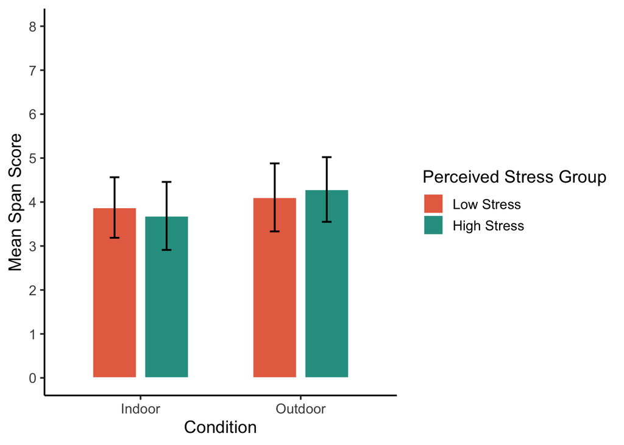

```r
p_span_condition_stress_bar <- ggplot(
  as.data.frame(emmeans(a2_span_stress, ~ condition * stress_group)),
  aes(
    x = condition,
    y = emmean,
    fill = stress_group
  )
) +
  geom_col(
    position = position_dodge(width = 0.65),
    width = 0.55,
    color = "white"
  ) +
  geom_errorbar(
    aes(
      ymin = lower.CL,
      ymax = upper.CL
    ),
    position = position_dodge(width = 0.65),
    width = 0.12,
    linewidth = 0.7
  ) +
  labs(
    x = "Condition",
    y = "Mean Span Score",
    fill = "Perceived Stress Group"
  ) +
  scale_fill_manual(
    values = c(
      "Low Stress" = "#E76F51",
      "High Stress" = "#2A9D8F"
    )
  ) +
  scale_y_continuous(
    breaks = seq(0, 8, 1)
  ) +
  coord_cartesian(
    ylim = c(0, 8)
  ) +
  theme_classic(
    base_size = 14
  )

p_span_condition_stress_bar
```

*The figure displays mean span scores for low- and high-stress participants across the indoor and outdoor conditions. Both stress groups showed slightly higher mean scores in the outdoor condition compared to the indoor condition, with high-stress participants showing a slightly larger descriptive difference (Indoor M = 3.68 vs. Outdoor M = 4.29) than low-stress participants (Indoor M = 3.88 vs. Outdoor M = 4.11). The error bars for each group overlap with one another, which lines up with the fact that the interaction was not statistically significant*

### Export Figures

```r
if (!dir.exists("figures")) {
  dir.create("figures")
}

ggsave(
  filename = "figures/span_condition_sex_interaction_plot.svg",
  plot = p_span_condition_sex_bar,
  width = 7,
  height = 5
)

ggsave(
  filename = "figures/span_condition_stress_interaction_plot.svg",
  plot = p_span_condition_stress_bar,
  width = 7,
  height = 5
)
```

*Both figures were exported as .svg files to the figures/ directory for use in the research poster*

## Results Summary

*Overall, none of our five predictions were supported by the results. Participants who took an outdoor break did not score significantly higher on the memory task compared to those who took an indoor break (H1). Stress level did not significantly predict how well someone performed on the memory task (H2), and male and female participants scored about the same overall (H3). The outdoor benefit also did not depend on how stressed someone was (H4) or whether they were male or female (H5). While some small trends did show up in the data — like female participants and high-stress participants scoring slightly higher in the outdoor condition — these differences were not large enough to be statistically meaningful*